# Определение возраста покупателей

**Описание проекта**

Сетевой супермаркет «Хлеб-Соль» внедряет систему компьютерного зрения для обработки фотографий покупателей. Фотофиксация в прикассовой зоне поможет определять возраст клиентов, чтобы: Анализировать покупки и предлагать товары, которые могут заинтересовать покупателей этой возрастной группы; Контролировать добросовестность кассиров при продаже алкоголя. Постройте модель, которая по фотографии определит приблизительный возраст человека. В вашем распоряжении набор фотографий людей с указанием возраста.

**Инструкция по выполнению проекта**

1. Проведите исследовательский анализ набора фотографий.
2. Подготовьте данные к обучению.
3. Обучите нейронную сеть и рассчитайте её качество.

**План**

1. Загрузка
2. Исследовательский анализ данных
   - Возраст
   - Содержание фотографий
   - Размер фотографий
3. Обучение модели
4. Анализ обученной модели

**Содержание**

1. Загрузка
2. Исследовательский анализ данных  
   2.1. Статистика - возраст  
   2.2. Содержание фотографий  
   2.3. Размер фотографий  
   2.4. Выводы
3. Обучение модели
4. Анализ обученной модели
5. Чек-лист

```python
import pandas as pd
import numpy as np
import matplotlib.pyplot as plt

from PIL import Image
```

```python
plt.rcParams["figure.figsize"] = (7,7)
plt.rc('axes', titlesize='x-large')
RANDOM = 0
#pd.set_option('max_rows', 60)
```

## 1. Загрузка

```python
ldf = pd.read_csv('/datasets/faces/labels.csv') #labels DF
```

```python
ldf.head()
```

|  | file_name | real_age |
| --- | --- | --- |
| 0 | 000000.jpg | 4 |
| 1 | 000001.jpg | 18 |
| 2 | 000002.jpg | 80 |
| 3 | 000003.jpg | 50 |
| 4 | 000004.jpg | 17 |

```python
ldf.tail()
```

|  | file_name | real_age |
| --- | --- | --- |
| 7586 | 007608.jpg | 14 |
| 7587 | 007609.jpg | 37 |
| 7588 | 007610.jpg | 28 |
| 7589 | 007611.jpg | 20 |
| 7590 | 007612.jpg | 47 |

```python
ldf.shape
```

```
(7591, 2)
```

```python
ldf.info()
```

```
<class 'pandas.core.frame.DataFrame'>
RangeIndex: 7591 entries, 0 to 7590
Data columns (total 2 columns):
 #   Column     Non-Null Count  Dtype
---  ------     --------------  -----
 0   file_name  7591 non-null   object
 1   real_age   7591 non-null   int64
dtypes: int64(1), object(1)
memory usage: 118.7+ KB
```

```python
ldf.duplicated().sum()
```

```
0
```

**Выводы:**

Таблица содержит названия файлов-фотографий и "реальный" возраст людей на них. Реальным здесь он называется в противовес воспринимаемому наблюдателем, являющегося частью оригинального статьи - источника набора данных. В рамках проекта мы просто рассматриваем `real_age` как возраст.

Пропусков нет. Дубликатов нет.

## 2. Исследовательский анализ данных

### 2.1. Статистика - возраст

```python
ldf.real_age.describe()
```

```
count    7591.000000
mean       31.201159
std        17.145060
min         1.000000
25%        20.000000
50%        29.000000
75%        41.000000
max       100.000000
Name: real_age, dtype: float64
```

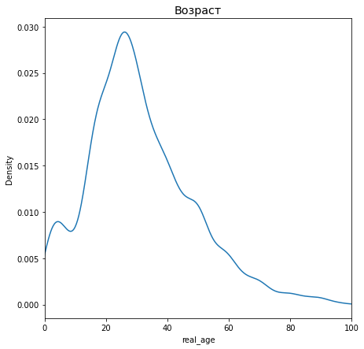

```python
ldf.real_age.plot(kind='kde', xlim=(0, 100)).set(title='Возраст', xlabel='real_age');
```

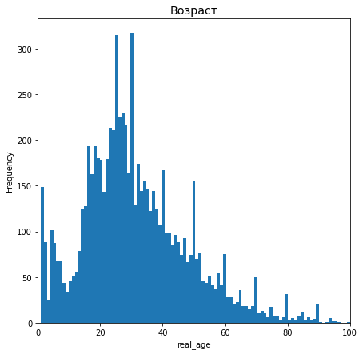

```python
ldf.real_age.plot(kind='hist', bins=100, xlim=(0, 100)).set(title='Возраст', xlabel='real_age');
```

### 2.2. Содержание фотографий

```python
ldf[ldf.real_age < 5].shape[0]
```

```
363
```

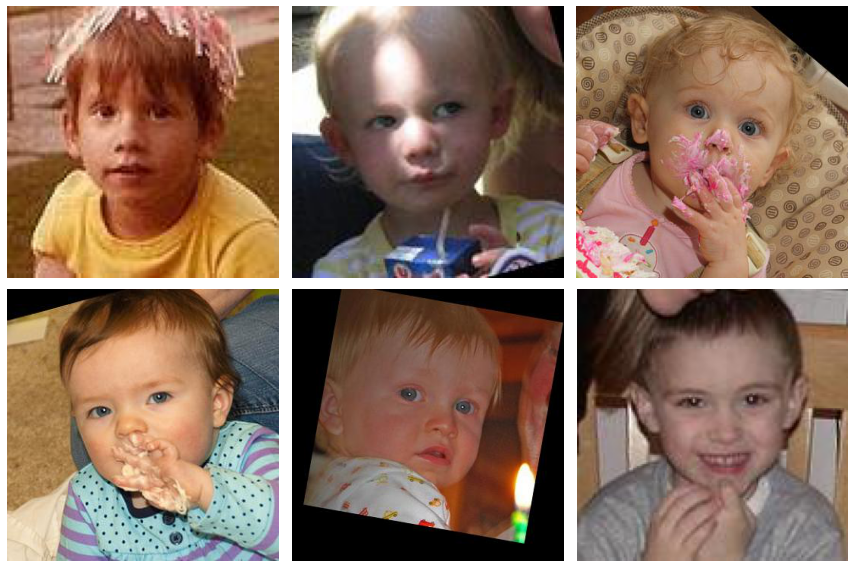

```python
fig, axs = plt.subplots(2, 3, figsize=(12,8))
for smpl_img, ax in zip(ldf[ldf.real_age < 5].head(6).file_name, axs.flatten()):
    plt.sca(ax)
    plt.imshow(np.array(Image.open('/datasets/faces/final_files/'+smpl_img)))
    plt.axis('off')
plt.tight_layout()
```

Дети вряд ли пригодны для задач магазина, их идентификация может помочь предоставить рекомендации взрослым, но это, скорее, выходит за рамки проекта.

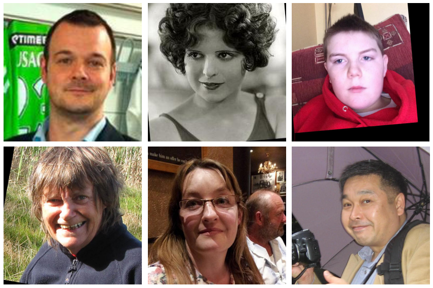

```python
fig, axs = plt.subplots(2, 3, figsize=(12,8))
for smpl_img, ax in zip(ldf[(ldf.real_age > 5) & (ldf.real_age < 80)].sample(6, random_state=RANDOM).file_name, axs.flatten()):
    plt.sca(ax)
    plt.imshow(np.array(Image.open('/datasets/faces/final_files/'+smpl_img)))
    plt.axis('off')
plt.tight_layout()
```

Фотографии принадлежат разным стилям, и возможно, разным временным периодам, в целом фотографии не стандартны, и имеют значительную вариацию помимо возраста, это может осложнить обучение, также некоторые фотографии содержат более одного лица.

[figure not shown]

```python
fig, axs = plt.subplots(2, 3, figsize=(12, 8))
for smpl_img, ax in zip(ldf[ldf.real_age > 80].head(6).file_name, axs.flatten()):
    plt.sca(ax)
    plt.imshow(np.array(Image.open('/datasets/faces/final_files/'+smpl_img)))
    plt.axis('off')
plt.tight_layout()
```

Возраст людей на изображениях, визуально, соответствует значениям в таблице.

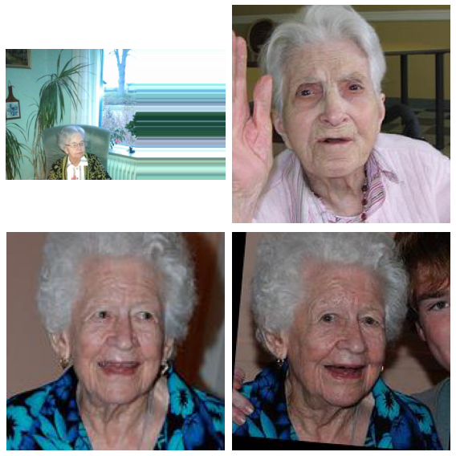

```python
fig, axs = plt.subplots(2, 2, figsize=(8,8))
for smpl_img, ax in zip(ldf[ldf.real_age > 95].head(6).file_name, axs.flatten()):
    plt.sca(ax)
    plt.imshow(np.array(Image.open('/datasets/faces/final_files/'+smpl_img)))
    plt.axis('off')
plt.tight_layout()
```

```python
ldf[ldf.real_age > 95]
```

|  | file_name | real_age |
| --- | --- | --- |
| 2661 | 002661.jpg | 100 |
| 5806 | 005806.jpg | 97 |
| 6248 | 006252.jpg | 96 |
| 6379 | 006383.jpg | 96 |

```python
#ldf.drop(6379, inplace=True) - преподаватель сказал что пред обработку не следует проводить
```

**Вывод:**

Нет разделения на мужчин и женщин, что может усложнить оценку. Отсутствие однообразия среди изображений усложняет задачу, но делает более вероятным качественное определение случайного покупателя зашедшего в магазин.

Набор данных не идеален - присутствуют изображения малолетних детей, изображения одних и тех же людей, изображения на которых больше одного лица. В рамках настоящей задачи, возможно, имеет смысл отбросить их, но здесь - оставляем.

### 2.3. Размер фотографий

```python
img_sizes = ldf.sample(20, random_state=RANDOM).copy()
img_sizes['size'] = img_sizes.file_name.map(
    lambda x: Image.open('/datasets/faces/final_files/'+x).size
)
img_sizes
```

|  | file_name | real_age | size |
| --- | --- | --- | --- |
| 7531 | 007553.jpg | 40 | (163, 163) |
| 1785 | 001785.jpg | 46 | (1597, 1597) |
| 6638 | 006643.jpg | 62 | (443, 443) |
| 4721 | 004721.jpg | 25 | (217, 217) |
| 6651 | 006656.jpg | 35 | (234, 234) |
| 4923 | 004923.jpg | 38 | (229, 230) |
| 6283 | 006287.jpg | 25 | (152, 152) |
| 224 | 000224.jpg | 60 | (553, 553) |
| 3915 | 003915.jpg | 24 | (122, 122) |
| 273 | 000273.jpg | 19 | (508, 508) |
| 1261 | 001261.jpg | 25 | (520, 519) |
| 2465 | 002465.jpg | 50 | (619, 619) |
| 3266 | 003266.jpg | 24 | (565, 565) |
| 2749 | 002749.jpg | 28 | (594, 594) |
| 5758 | 005758.jpg | 13 | (201, 201) |
| 152 | 000152.jpg | 25 | (1832, 1832) |
| 864 | 000864.jpg | 54 | (1009, 1009) |
| 3161 | 003161.jpg | 28 | (524, 524) |
| 2141 | 002141.jpg | 24 | (755, 755) |
| 4553 | 004553.jpg | 87 | (461, 460) |

**Выводы:**

Размер фотографий не стандартизирован, во время обучения все будут приведены к размеру (224, 224) - размеру на котором обучалась ResNet, что может привести к некоторой потере данных, но в целом достаточно для оценки возраста.

### 2.4. Выводы

Пропусков нет. Дубликатов нет. Возраст от 1 до 100 с медианой 29.

Широкий перечень возрастов, стилей, и людей на фотографиях, скорее всего приведёт к усложнению работы алгоритма. Возможно, на практике, имело бы смысл разбить задачу на две или более, сначала определить принадлежность к возрастной и/или другим группам, таким как пол, а потом оценивать возраст.

Преимуществом такого разнообразия является подготовка к реальным условиям, где может понадобится оценивать возраст очень разных людей.

С точки зрения легенды проекта часть изображений не пригодна для обучения - дубликаты, фотографии содержащие более одного человека, дети, в рамках проекта не отбрасываем такие, но на практике было бы оправдано почистить фотографии.

Размеры фотографий не стандартны, потребуется во время обучения изменять их для корректной работы модели и сохранения памяти.

## 3. Обучение модели

Перенесите сюда код обучения модели и её результат вывода на экран.

(Код в этом разделе запускается в отдельном GPU-тренажёре, поэтому оформлен не как ячейка с кодом, а как код в текстовой ячейке)

```
import pandas as pd
from tensorflow.keras.preprocessing.image import ImageDataGenerator
from tensorflow.keras.models import Sequential
from tensorflow.keras.applications.resnet import ResNet50
from tensorflow.keras.layers import Dense, GlobalAveragePooling2D
from tensorflow.keras.optimizers import Adam


def load_train(path):
    RANDOM = 12345
    df = pd.read_csv(path+'/labels.csv')

    train_imdagen = ImageDataGenerator(
        rescale=1./255,
        validation_split=0.25,
        horizontal_flip=True,
        height_shift_range=0.2,
        width_shift_range=0.2
    )
    train_flow = train_imdagen.flow_from_dataframe(
        dataframe=df,
        directory=path+'/final_files',
        seed=RANDOM,
        x_col='file_name',
        y_col='real_age',
        target_size=(224, 224),
        batch_size=16,
        class_mode='raw',
        subset='training'
    )

    return train_flow


def load_test(path):
    RANDOM = 12345
    df = pd.read_csv(path+'/labels.csv')

    test_imdagen = ImageDataGenerator(
        rescale=1./225,
        validation_split=0.25
    )
    test_flow = test_imdagen.flow_from_dataframe(
        dataframe=df,
        directory=path+'/final_files',
        seed=RANDOM,
        x_col='file_name',
        y_col='real_age',
        target_size=(224, 224),
        batch_size=16,
        class_mode='raw',
        subset='validation'
    )

    return test_flow


def create_model(input_shape):

    optimizer = Adam(lr=0.0001)

    backbone = ResNet50(input_shape=input_shape,
                        weights='/datasets/keras_models/resnet50_weights_tf_dim_ordering_tf_kernels_notop.h5',
                        include_top=False)
#    backbone.trainable = False

    model = Sequential()
    model.add(backbone)
    model.add(GlobalAveragePooling2D())
    model.add(Dense(128, activation='relu'))
    model.add(Dense(54, activation='relu'))
    model.add(Dense(1, activation='relu'))

    model.compile(loss='mse',
                  optimizer=optimizer,  # 'adam',
                  metrics=['mae'])

    model.summary()

    return model


def train_model(model, train_flow, val_flow, batch_size=None, epochs=10,
                steps_per_epoch=None, validation_steps=None):

    model.fit(train_flow,
              validation_data=val_flow,
              batch_size=batch_size,
              epochs=epochs,
              steps_per_epoch=steps_per_epoch,
              validation_steps=validation_steps,
              verbose=2)

    return model
```

```
Model: "sequential"
_________________________________________________________________
Layer (type)                 Output Shape              Param #
=================================================================
resnet50 (Model)             (None, 7, 7, 2048)        23587712
_________________________________________________________________
global_average_pooling2d (Gl (None, 2048)              0
_________________________________________________________________
dense (Dense)                (None, 128)               262272
_________________________________________________________________
dense_1 (Dense)              (None, 54)                6966
_________________________________________________________________
dense_2 (Dense)              (None, 1)                 55
=================================================================
Total params: 23,857,005
Trainable params: 23,803,885
Non-trainable params: 53,120
_________________________________________________________________
<class 'tensorflow.python.keras.engine.sequential.Sequential'>
WARNING:tensorflow:sample_weight modes were coerced from
  ...
    to
  ['...']
WARNING:tensorflow:sample_weight modes were coerced from
  ...
    to
  ['...']
Train for 356 steps, validate for 119 steps
Epoch 1/10
2023-12-27 22:36:29.592728: I tensorflow/stream_executor/platform/default/dso_loader.cc:44] Successfully opened dynamic library libcublas.so.10
2023-12-27 22:36:29.879788: I tensorflow/stream_executor/platform/default/dso_loader.cc:44] Successfully opened dynamic library libcudnn.so.7
356/356 - 108s - loss: 206.7110 - mae: 10.6549 - val_loss: 296.4802 - val_mae: 12.8328
Epoch 2/10
356/356 - 102s - loss: 99.6775 - mae: 7.6108 - val_loss: 141.6091 - val_mae: 8.9944
Epoch 3/10
356/356 - 102s - loss: 78.9620 - mae: 6.7909 - val_loss: 137.0538 - val_mae: 8.4728
Epoch 4/10
356/356 - 102s - loss: 66.1477 - mae: 6.2376 - val_loss: 82.7081 - val_mae: 6.8926
Epoch 5/10
356/356 - 102s - loss: 51.7769 - mae: 5.5544 - val_loss: 85.4819 - val_mae: 7.0516
Epoch 6/10
356/356 - 102s - loss: 43.7613 - mae: 5.0718 - val_loss: 86.4060 - val_mae: 6.7407
Epoch 7/10
356/356 - 102s - loss: 39.2041 - mae: 4.8058 - val_loss: 82.9259 - val_mae: 6.5971
Epoch 8/10
356/356 - 97s - loss: 32.4962 - mae: 4.3992 - val_loss: 108.2794 - val_mae: 7.8028
Epoch 9/10
356/356 - 95s - loss: 29.9775 - mae: 4.1990 - val_loss: 81.6475 - val_mae: 6.4852
Epoch 10/10
356/356 - 92s - loss: 27.5794 - mae: 4.0232 - val_loss: 77.5459 - val_mae: 6.6744
WARNING:tensorflow:sample_weight modes were coerced from
  ...
    to
  ['...']
119/119 - 10s - loss: 77.5459 - mae: 6.6744
Test MAE: 6.6744
```

## 4. Анализ обученной модели

В качестве источника данных для обучения и оценки модели используем потоки на основе таблицы с ярлыками фотографий. Для того чтобы добавить аугментацию в обучающий поток, при этом сохранив разделение, используем одинаковый генератор случайных чисел (seed - зерно). Ввиду необходимости сохранять весь ход в рамках функций, переменные содержащие его и таблицу приходится инициализировать отдельно для загрузчиков обучающей и контрольной выборки.

Фотографии приводим к размеру (224, 224), размеру на котором обучалась ResNet, и берём по 16 на пачку(batch), таким образом 7591/16 ~ 475 пачек: 356 обучающая, 119 контрольная выборки. Эти же значения дают нам количество шагов для обучающей эпохи и контрольной оценки.

Для конструкции модели используем `mse` как функцию потери и `mae` для оценки качества модели. В качестве функции потерь для этой модели `mae` и `mse` работает более менее одинакого, но `mse` даёт более надёжное улучшение результатов с каждой эпохой. Оптимизатор адам с скоростью обучения 0.0001 - ниже стандартной. Задача довольно сложная, это оправдывает более низкую скорость.

В качестве модели используем костяк ResNet, обучение **не** замораживаем. Набор данных достаточно мал чтобы о переобучении стоило беспокоиться, но на 10 эпохах это ещё не слишком большая проблема, а качество обучения значительно падает с замороженным костяком, ввиду сложности задачи определения возраста по фотографии, которая требует большого количество признаков для точности. Однако если заходить за 10 эпох потери из-за переобучения становятся довольно большими, т.к. модель переходит от поиска закономерностей к подгонке под обучающую выборку.

После костяка добавляем стандартный для ResNet слой средних значений по фильтрам, он позволяет привести количество значений параметров к более удобному для дальнейшей оценки числу, некоторым образом подводя итоги работы ResNet.

После этого два полносвязных слоя концентрируют параметры полученные до этого, и передают линейной регрессии для оценки непосредственно возраста. В качестве активатора для всех трёх используем `relu` - возраст не может быть отрицательным, поэтому данная функция здесь хорошо подходит. Примечательно что увеличение числи нейронов в двух последних слоях и добавление 3го слоя не улучшают качество модели, таким образом основная цель их - подготовить параметры для оценки линейной регрессией.

Стоит обратить внимание на зигзагообразность значения потерь на проверочной выборке, от эпохи к эпохе она может расти и падать, однако в отличии от `mae` её значения дальше от требуемого барьера, и боле надёжно улучшаются по прошествии нескольких эпох, что говорит о предпочтительности `mse` для обучения данной модели.